# prelim_analysis

Gabriel De La Rosa

7/13/2021

# US Ocean Pollution hotspots

This document shows our preliminary analysis that estimates nitrogen and phosphorous loading to US waters.

We include 3 main sources for nutrient loading:

- River loading (N and P)
- Sewage outfalls (N and P)
- Atmospheric Deposition (N)

## Methods

### River Plumes

River plumes are estimated from [SPARROW](https://www.usgs.gov/mission-areas/water-resources/science/sparrow-modeling-estimating-nutrient-sediment-and-dissolved?qt-science_center_objects=0#qt-science_center_objects) models, which estimate nutrient flows in stream reaches for the entire US. We parse anthropogenic nutrients for each stream reach that flows into the ocean, then plume those nutrients into the ocean.

River plume extent is estimated using the equation from Warrick & Farnsworth, 2017:

$P = c*A^\beta)$

where p is the size of the plume, c is a plume size factor related to discharge, A is the upstream watershed area and $\beta$ is constant scaling factor. We use c = 0.5 and $\beta$ = 0.65, which are the most commonly found ratios according to Warrick and Farnsworth.

Plume size for each river plume is calculated based on the upstream watershed area. Effluent is plumed into the ocean starting at the spatial location of each rivermouth. Plumes are expanded iteratively using a four-neighbor rule until the total area of plumed cells exceeds the predicted plume size in the above area. Only cells within the EEZ are included in plume expansion, i.e. cells outside the ocean never contain any of the plume.

Once the spatial extent of a plume is determined, pollutant mass per raster cell is calculated by first dividing the total mass of the pollutant by the number of expansions needed to achieve the calculated plume size. The total mass of pollutant is distributed equally over each expansion, to simulate increasing dilution as the distance from the point source increases.

### Outfalls

Outfall spatial extents are complex and hard to generalize. For our purposes, we recycle the plume relationship calculated for rivers and apply them to outfall plumes. Outfalls have an initial velocity and are subject to more complicated oceanographic conditions than river plumes, however, as a general overview, our methods roughly estimate plume location and extent.

First, because outfalls do not have a watershed size, we first predicted plume area based on the flow rate (CFS) of each river. To do this, we used linear regression using R’s lm() function. The results are as follows…

Residual standard error: 53.48 on 3419 degrees of freedom Multiple R-squared: 0.859, Adjusted R-squared: 0.8589 F-statistic: 2.083e+04 on 1 and 3419 DF, p-value: < 2.2e-16

Giving us a relationship of:

Plume area = .0145240 * FLOWcfs + 7.478210

We then apply the same plume model as for river nutrients, where the plume area is calculated, plumes are expanded via a 4-neighbor rule until the area of the plume exceeds the calculated plume area, then the pollutant is distributed to each cell by dividing the same amount of pollutant over all the new cells contained in each expansion.

### Deposition

Deposition loading is estimated using data from [NOAA](https://daac.ornl.gov/cgi-bin/dsviewer.pl?ds_id=830), where the 1993 dataset seems to be the industry standard.

[output not shown]

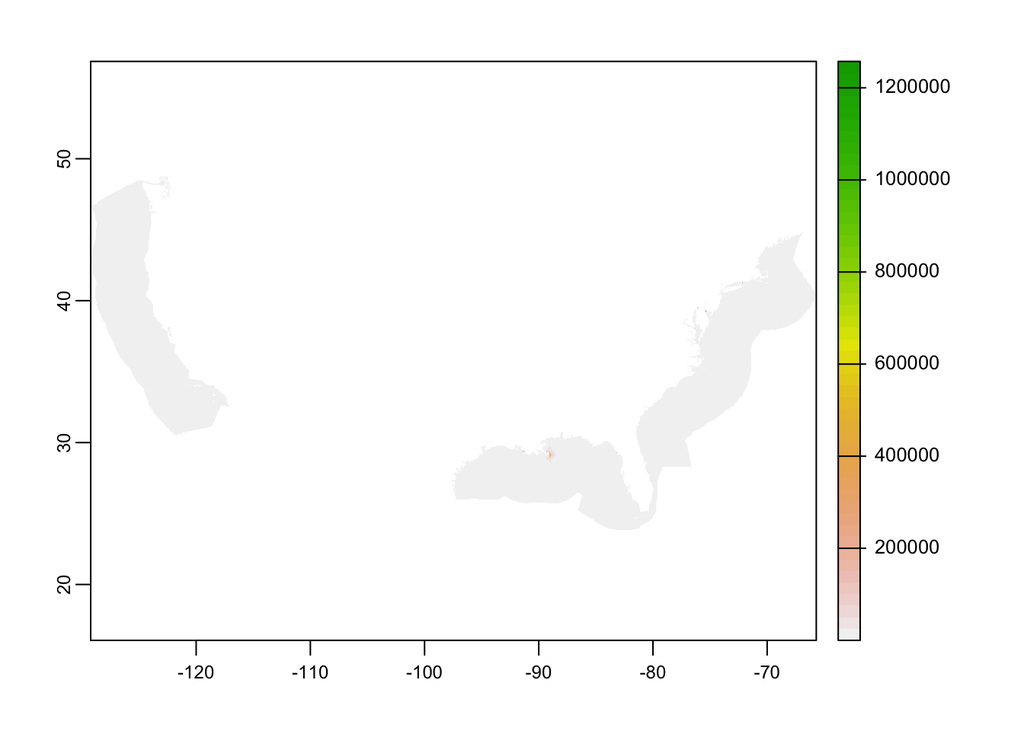

# Results:

To determine where anthropogenic nutrients are most likely to drive ecosystem change, we calculate the ratio of pollutant (N or P) input per year to the total mass of natural nutrients in surface water. High anthropogenic nutrient ratios are more likely to cause eutrophication, and be good targets for seaweed aquaculture as a nutrient remediation strategy.

Results are calculated on a 0.2 degree grid.

### Nitrogen ratio

[interactive chart not shown]

### Phosphorus ratio

[interactive chart not shown]

# Nutrients in marine space available to aquaculture

While the nutrient ratios highlight where targeted aquaculture for assimilation may be most effective, we also wanted to look and see if there is available marine space around nutrient pollution hotspots for seaweed aquaculture projects. To do this, we performed a simple exclusion analysis for the entire US. We considered marine space that contained any of the following to be unavailable to seaweed aquaculture:

- Shipping lanes
- MPA’s **
- Submarine Cables
- Undersea Pipelines
- Military restricted areas
- Oil and gas platforms or wells
- Depth (below 10m or above 100m)

We have not yet considered biological suitability for any seaweeds.

### Results including the full MPA layer from NOAA:

According to a quick calculation, 25.36% of anthropogenic nitrogen inputs fall within available marine space, and 19.42% anthropogenic phosphorus exists in available marine space.

[interactive chart not shown]

### Results with limited MPA layer:

Our MPA layer contains several large zones classified as “Non-MPA Programmatic Species/Habitat/Fisheries Management Plan”, and includes areas like the Pelagic Sargassum Habitat Restricted Area, which is just a no-take zone for Sargassum. We’re double checking that all of these zones still allow aquaculture, so we also performed our exclusion analysis without the Non-MPA zones:

According to a quick calculation, only 57.84% of anthropogenic nitrogen inputs fall within available marine space, and only 28.12% phosphorus exists in available marine space, if we exclude Non-MPA Programmatic Managment zones.

## Calculating rough nitrogen uptake potential for species:

- Saccharina latissima can remove ~2500 kg/ha/yr N from https://link.springer.com/article/10.1007%2Fs10811-014-0519-8
- Gracilaria gracilis can remove ~1.15 tons/ha/year N from Anderson and Levitt, 1999 (https://www.sciencedirect.com/science/article/pii/S0022098101003872)
- Giant kelp? yeild is 200 tonnes/ha/yr (Buschmann 2014) tissue content is 0.03 N (Ilan Somer) so…200*0.03 = 6 tons N/ha/yr

To estimate the potential nutrient uptake of seaweed aquaculture in the US, we estimate total nutrient uptake of three different seaweed species (sacharina latissima, gracilaria gracilis, macrocystis pyrifera).

Using yield estimates combined with tissue nitrogen content estimates for each target species, we estimate the potential uptake of a single 0.2x0.2 raster cell planted completely with each target species. Then, we compare the potential nutrient remediation of each raster cell to the total nitrogen pollution in each cell, resulting in the percentage of nutrient pollution that each species can mitigate in each cell.

The resulting maps are below:

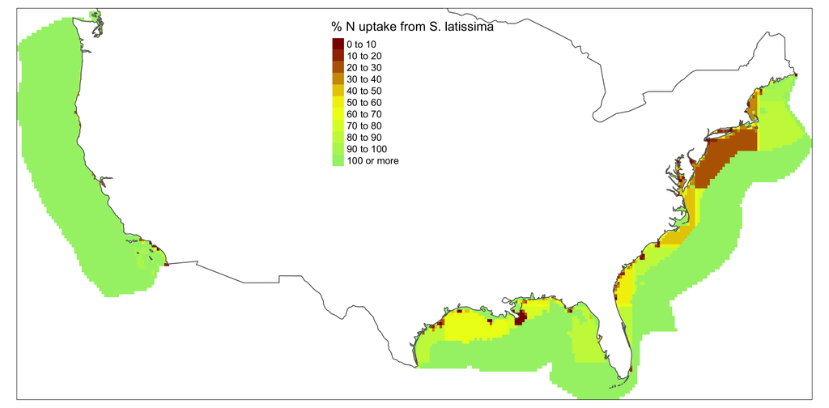

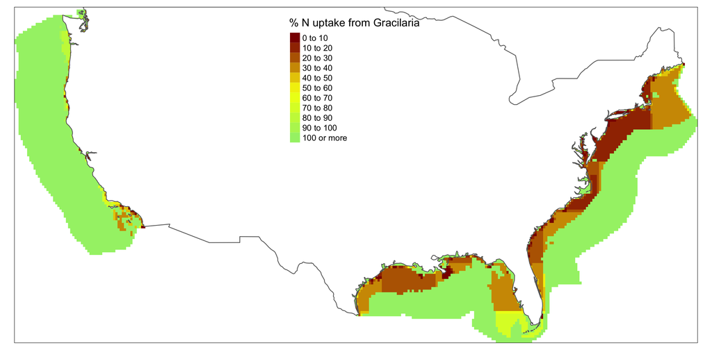

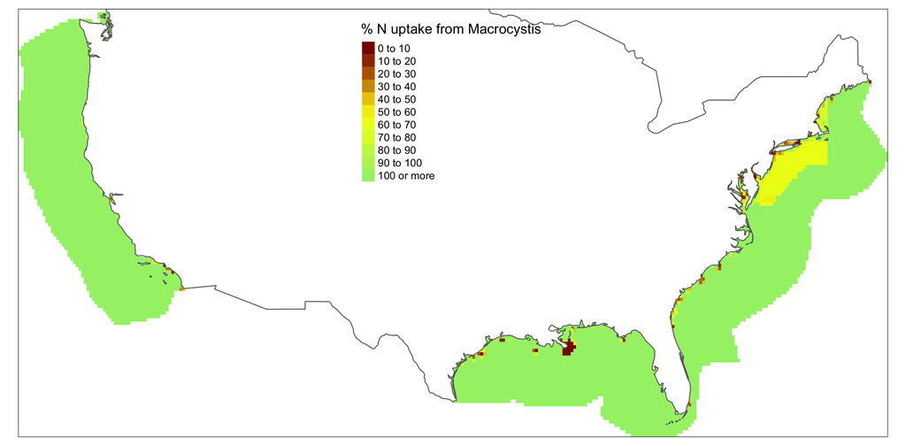

Initial conclusions for these maps are that while seaweeds can play a significant role in nutrient uptake in some areas, seaweed aquaculture is not a complete solution to highly polluted local areas, such as the Mississipi River plume. However, a side benefit of offshore seaweed aquaculture is significant potential to mitigate nitrogen deposition to open ocean environments.